# Part I - Prosper Loan Data Exploration

## Preliminary Wrangling

> Data Wrangling process done for exploratory data analysis.

```python
# Import all packages and set plots to be embedded inline
import numpy as np
import pandas as pd
import matplotlib.pyplot as plt
import seaborn as sb

%matplotlib inline
```

```python
# Load dataset
prosperLoanData = pd.read_csv('prosperLoanData.csv')

# View first 5 columns of data
prosperLoanData.head()
```

|  | ListingKey | ListingNumber | ListingCreationDate | CreditGrade | Term | LoanStatus | ClosedDate | BorrowerAPR | BorrowerRate | LenderYield | ... | LP_ServiceFees | LP_CollectionFees | LP_GrossPrincipalLoss | LP_NetPrincipalLoss | LP_NonPrincipalRecoverypayments | PercentFunded | Recommendations | InvestmentFromFriendsCount | InvestmentFromFriendsAmount | Investors |
| --- | --- | --- | --- | --- | --- | --- | --- | --- | --- | --- | --- | --- | --- | --- | --- | --- | --- | --- | --- | --- | --- |
| 0 | 1021339766868145413AB3B | 193129 | 2007-08-26 19:09:29.263000000 | C | 36 | Completed | 2009-08-14 00:00:00 | 0.16516 | 0.1580 | 0.1380 | ... | -133.18 | 0.0 | 0.0 | 0.0 | 0.0 | 1.0 | 0.0 | 0.0 | 0.0 | 258.0 |
| 1 | 10273602499503308B223C1 | 1209647 | 2014-02-27 08:28:07.900000000 | NaN | 36 | Current | NaN | 0.12016 | 0.0920 | 0.0820 | ... | 0.00 | 0.0 | 0.0 | 0.0 | 0.0 | 1.0 | 0.0 | 0.0 | 0.0 | 1.0 |
| 2 | 0EE9337825851032864889A | 81716 | 2007-01-05 15:00:47.090000000 | HR | 36 | Completed | 2009-12-17 00:00:00 | 0.28269 | 0.2750 | 0.2400 | ... | -24.20 | 0.0 | 0.0 | 0.0 | 0.0 | 1.0 | 0.0 | 0.0 | 0.0 | 41.0 |
| 3 | 0EF5356002482715299901A | 658116 | 2012-10-22 11:02:35.010000000 | NaN | 36 | Current | NaN | 0.12528 | 0.0974 | 0.0874 | ... | -108.01 | 0.0 | 0.0 | 0.0 | 0.0 | 1.0 | 0.0 | 0.0 | 0.0 | 158.0 |
| 4 | 0F023589499656230C5E3E2 | 909464 | 2013-09-14 18:38:39.097000000 | NaN | 36 | Current | NaN | 0.24614 | 0.2085 | 0.1985 | ... | -60.27 | 0.0 | 0.0 | 0.0 | 0.0 | 1.0 | 0.0 | 0.0 | 0.0 | 20.0 |

5 rows × 81 columns

```python
# Check the statistics of the data
prosperLoanData.describe()
```

|  | ListingNumber | Term | BorrowerAPR | BorrowerRate | LenderYield | EstimatedEffectiveYield | EstimatedLoss | EstimatedReturn | ProsperRating (numeric) | ProsperScore | ... | LP_ServiceFees | LP_CollectionFees | LP_GrossPrincipalLoss | LP_NetPrincipalLoss | LP_NonPrincipalRecoverypayments | PercentFunded | Recommendations | InvestmentFromFriendsCount | InvestmentFromFriendsAmount | Investors |
| --- | --- | --- | --- | --- | --- | --- | --- | --- | --- | --- | --- | --- | --- | --- | --- | --- | --- | --- | --- | --- | --- |
| count | 7.875400e+04 | 78754.000000 | 78740.000000 | 78754.000000 | 78754.000000 | 58624.000000 | 58624.000000 | 58624.000000 | 58624.000000 | 58624.000000 | ... | 78753.000000 | 78753.000000 | 78753.000000 | 78753.000000 | 78753.000000 | 78753.000000 | 78753.000000 | 78753.000000 | 78753.000000 | 78753.00000 |
| mean | 6.280081e+05 | 40.841202 | 0.218467 | 0.192454 | 0.182393 | 0.168505 | 0.080168 | 0.095962 | 4.076948 | 5.957884 | ... | -54.798232 | -14.719188 | 704.358420 | 684.539162 | 25.564718 | 0.998613 | 0.048049 | 0.023605 | 17.182178 | 80.46590 |
| std | 3.283799e+05 | 10.446825 | 0.080417 | 0.074842 | 0.074538 | 0.068546 | 0.046717 | 0.030414 | 1.672655 | 2.380677 | ... | 60.887988 | 115.837369 | 2393.477396 | 2360.935663 | 275.724028 | 0.017651 | 0.328729 | 0.247579 | 304.712386 | 103.29677 |
| min | 6.000000e+00 | 12.000000 | 0.006530 | 0.000000 | -0.010000 | -0.182700 | 0.004900 | -0.182700 | 1.000000 | 1.000000 | ... | -664.870000 | -9274.750000 | -94.200000 | -954.550000 | 0.000000 | 0.700000 | 0.000000 | 0.000000 | 0.000000 | 1.00000 |
| 25% | 4.004248e+05 | 36.000000 | 0.156290 | 0.133400 | 0.124000 | 0.115670 | 0.042400 | 0.074080 | 3.000000 | 4.000000 | ... | -73.180000 | 0.000000 | 0.000000 | 0.000000 | 0.000000 | 1.000000 | 0.000000 | 0.000000 | 0.000000 | 2.00000 |
| 50% | 6.003465e+05 | 36.000000 | 0.208790 | 0.183000 | 0.172500 | 0.161500 | 0.069900 | 0.091400 | 4.000000 | 6.000000 | ... | -34.430000 | 0.000000 | 0.000000 | 0.000000 | 0.000000 | 1.000000 | 0.000000 | 0.000000 | 0.000000 | 44.00000 |
| 75% | 8.944852e+05 | 36.000000 | 0.283700 | 0.250000 | 0.240000 | 0.224300 | 0.112000 | 0.116000 | 5.000000 | 8.000000 | ... | -13.900000 | 0.000000 | 0.000000 | 0.000000 | 0.000000 | 1.000000 | 0.000000 | 0.000000 | 0.000000 | 115.00000 |
| max | 1.255725e+06 | 60.000000 | 0.512290 | 0.497500 | 0.492500 | 0.319900 | 0.366000 | 0.283700 | 7.000000 | 11.000000 | ... | 32.060000 | 0.000000 | 25000.000000 | 25000.000000 | 21117.900000 | 1.004500 | 39.000000 | 33.000000 | 25000.000000 | 1035.00000 |

8 rows × 61 columns

```python
# Check data information
prosperLoanData.info()
```

```
<class 'pandas.core.frame.DataFrame'>
RangeIndex: 78754 entries, 0 to 78753
Data columns (total 81 columns):
ListingKey                             78754 non-null object
ListingNumber                          78754 non-null int64
ListingCreationDate                    78754 non-null object
CreditGrade                            20040 non-null object
Term                                   78754 non-null int64
LoanStatus                             78754 non-null object
ClosedDate                             38145 non-null object
BorrowerAPR                            78740 non-null float64
BorrowerRate                           78754 non-null float64
LenderYield                            78754 non-null float64
EstimatedEffectiveYield                58624 non-null float64
EstimatedLoss                          58624 non-null float64
EstimatedReturn                        58624 non-null float64
ProsperRating (numeric)                58624 non-null float64
ProsperRating (Alpha)                  58624 non-null object
ProsperScore                           58624 non-null float64
ListingCategory (numeric)              78753 non-null float64
BorrowerState                          74910 non-null object
Occupation                             76329 non-null object
EmploymentStatus                       77215 non-null object
EmploymentStatusDuration               73484 non-null float64
IsBorrowerHomeowner                    78753 non-null object
CurrentlyInGroup                       78753 non-null object
GroupKey                               9218 non-null object
DateCreditPulled                       78753 non-null object
CreditScoreRangeLower                  78338 non-null float64
CreditScoreRangeUpper                  78338 non-null float64
FirstRecordedCreditLine                78270 non-null object
CurrentCreditLines                     73500 non-null float64
OpenCreditLines                        73500 non-null float64
TotalCreditLinespast7years             78270 non-null float64
OpenRevolvingAccounts                  78753 non-null float64
OpenRevolvingMonthlyPayment            78753 non-null float64
InquiriesLast6Months                   78270 non-null float64
TotalInquiries                         77955 non-null float64
CurrentDelinquencies                   78270 non-null float64
AmountDelinquent                       73485 non-null float64
```

[output cut: 31 more lines]

```
LP_CustomerPayments                    78753 non-null float64
LP_CustomerPrincipalPayments           78753 non-null float64
LP_InterestandFees                     78753 non-null float64
LP_ServiceFees                         78753 non-null float64
LP_CollectionFees                      78753 non-null float64
LP_GrossPrincipalLoss                  78753 non-null float64
LP_NetPrincipalLoss                    78753 non-null float64
LP_NonPrincipalRecoverypayments        78753 non-null float64
PercentFunded                          78753 non-null float64
Recommendations                        78753 non-null float64
InvestmentFromFriendsCount             78753 non-null float64
InvestmentFromFriendsAmount            78753 non-null float64
Investors                              78753 non-null float64
dtypes: float64(59), int64(2), object(20)
memory usage: 48.7+ MB
```

```python
# Check number of rows and columns of data
prosperLoanData.shape
```

```
(78754, 81)
```

```python
# Check number of null values
prosperLoanData.isnull().sum()
```

```
ListingKey                                 0
ListingNumber                              0
ListingCreationDate                        0
CreditGrade                            58714
Term                                       0
LoanStatus                                 0
ClosedDate                             40609
BorrowerAPR                               14
BorrowerRate                               0
LenderYield                                0
EstimatedEffectiveYield                20130
EstimatedLoss                          20130
EstimatedReturn                        20130
ProsperRating (numeric)                20130
ProsperRating (Alpha)                  20130
ProsperScore                           20130
ListingCategory (numeric)                  1
BorrowerState                           3844
Occupation                              2425
EmploymentStatus                        1539
EmploymentStatusDuration                5270
IsBorrowerHomeowner                        1
CurrentlyInGroup                           1
GroupKey                               69536
DateCreditPulled                           1
CreditScoreRangeLower                    416
CreditScoreRangeUpper                    416
FirstRecordedCreditLine                  484
CurrentCreditLines                      5254
OpenCreditLines                         5254
                                       ...
TotalProsperLoans                      63510
TotalProsperPaymentsBilled             63510
OnTimeProsperPayments                  63510
ProsperPaymentsLessThanOneMonthLate    63510
ProsperPaymentsOneMonthPlusLate        63510
ProsperPrincipalBorrowed               63510
ProsperPrincipalOutstanding            63510
ScorexChangeAtTimeOfListing            65730
LoanCurrentDaysDelinquent                  1
LoanFirstDefaultedCycleNumber          67045
LoanMonthsSinceOrigination                 1
LoanNumber                                 1
LoanOriginalAmount                         1
LoanOriginationDate                        1
LoanOriginationQuarter                     1
MemberKey                                  1
MonthlyLoanPayment                         1
LP_CustomerPayments                        1
LP_CustomerPrincipalPayments               1
LP_InterestandFees                         1
LP_ServiceFees                             1
LP_CollectionFees                          1
LP_GrossPrincipalLoss                      1
LP_NetPrincipalLoss                        1
LP_NonPrincipalRecoverypayments            1
PercentFunded                              1
Recommendations                            1
InvestmentFromFriendsCount                 1
InvestmentFromFriendsAmount                1
Investors                                  1
Length: 81, dtype: int64
```

```python
# Check for duplicate rows
prosperLoanData.duplicated(subset=['ListingKey']).sum()
```

```
467
```

## Data Cleaning

```python
# Make copy of the original data
loan_df = prosperLoanData.copy()
```

```python
# View all columns to see which ones will be dropped
loan_df.columns
```

```
Index(['ListingKey', 'ListingNumber', 'ListingCreationDate', 'CreditGrade',
       'Term', 'LoanStatus', 'ClosedDate', 'BorrowerAPR', 'BorrowerRate',
       'LenderYield', 'EstimatedEffectiveYield', 'EstimatedLoss',
       'EstimatedReturn', 'ProsperRating (numeric)', 'ProsperRating (Alpha)',
       'ProsperScore', 'ListingCategory (numeric)', 'BorrowerState',
       'Occupation', 'EmploymentStatus', 'EmploymentStatusDuration',
       'IsBorrowerHomeowner', 'CurrentlyInGroup', 'GroupKey',
       'DateCreditPulled', 'CreditScoreRangeLower', 'CreditScoreRangeUpper',
       'FirstRecordedCreditLine', 'CurrentCreditLines', 'OpenCreditLines',
       'TotalCreditLinespast7years', 'OpenRevolvingAccounts',
       'OpenRevolvingMonthlyPayment', 'InquiriesLast6Months', 'TotalInquiries',
       'CurrentDelinquencies', 'AmountDelinquent', 'DelinquenciesLast7Years',
       'PublicRecordsLast10Years', 'PublicRecordsLast12Months',
       'RevolvingCreditBalance', 'BankcardUtilization',
       'AvailableBankcardCredit', 'TotalTrades',
       'TradesNeverDelinquent (percentage)', 'TradesOpenedLast6Months',
       'DebtToIncomeRatio', 'IncomeRange', 'IncomeVerifiable',
       'StatedMonthlyIncome', 'LoanKey', 'TotalProsperLoans',
       'TotalProsperPaymentsBilled', 'OnTimeProsperPayments',
       'ProsperPaymentsLessThanOneMonthLate',
       'ProsperPaymentsOneMonthPlusLate', 'ProsperPrincipalBorrowed',
       'ProsperPrincipalOutstanding', 'ScorexChangeAtTimeOfListing',
       'LoanCurrentDaysDelinquent', 'LoanFirstDefaultedCycleNumber',
       'LoanMonthsSinceOrigination', 'LoanNumber', 'LoanOriginalAmount',
       'LoanOriginationDate', 'LoanOriginationQuarter', 'MemberKey',
       'MonthlyLoanPayment', 'LP_CustomerPayments',
       'LP_CustomerPrincipalPayments', 'LP_InterestandFees', 'LP_ServiceFees',
       'LP_CollectionFees', 'LP_GrossPrincipalLoss', 'LP_NetPrincipalLoss',
       'LP_NonPrincipalRecoverypayments', 'PercentFunded', 'Recommendations',
       'InvestmentFromFriendsCount', 'InvestmentFromFriendsAmount',
       'Investors'],
      dtype='object')
```

```python
# Columns with too many missing values and redundant data
cols_not_needed = ['ListingNumber','TradesNeverDelinquent (percentage)','DebtToIncomeRatio',
                   'ProsperRating (numeric)','EstimatedLoss','AvailableBankcardCredit',
                   'InvestmentFromFriendsCount','InvestmentFromFriendsAmount',
                   'PublicRecordsLast12Months','LP_NonPrincipalRecoverypayments','Investors',
                   'ProsperRating (Alpha)','ScorexChangeAtTimeOfListing','EstimatedReturn',
                   'CreditScoreRangeLower','GroupKey','PercentFunded','LP_CollectionFees',
                   'EstimatedEffectiveYield','DateCreditPulled','EmploymentStatusDuration',
                   'LP_NetPrincipalLoss','ProsperPrincipalOutstanding','TotalCreditLinespast7years',
                   'ListingCreationDate','CreditGrade','OpenRevolvingMonthlyPayment',
                   'OpenRevolvingAccounts','BankcardUtilization','TotalInquiries',
                   'PublicRecordsLast10Years','LP_ServiceFees','MonthlyLoanPayment','OpenCreditLines',
                   'ClosedDate','Recommendations','CurrentCreditLines','RevolvingCreditBalance',
                   'LP_GrossPrincipalLoss','TradesOpenedLast6Months','LoanKey',
                   'LoanFirstDefaultedCycleNumber','LoanNumber','DelinquenciesLast7Years',
                   'TotalTrades','MemberKey','InquiriesLast6Months','FirstRecordedCreditLine',
                   'TotalProsperLoans','TotalProsperPaymentsBilled','OnTimeProsperPayments',
                   'ProsperPaymentsLessThanOneMonthLate','ProsperPaymentsOneMonthPlusLate',
                   'ProsperPrincipalBorrowed','CurrentlyInGroup', 'CreditScoreRangeUpper',
                   'CurrentDelinquencies', 'AmountDelinquent','IncomeVerifiable', 'StatedMonthlyIncome',
                   'LoanCurrentDaysDelinquent','LoanMonthsSinceOrigination','LoanOriginationDate',
                   'LoanOriginationQuarter', 'LP_CustomerPayments',
                   'LP_CustomerPrincipalPayments', 'LP_InterestandFees']

# Drop columns not needed
loan_df.drop(columns=cols_not_needed, axis=1, inplace=True)

# View remaining columns
loan_df.columns
```

```
Index(['ListingKey', 'Term', 'LoanStatus', 'BorrowerAPR', 'BorrowerRate',
       'LenderYield', 'ProsperScore', 'ListingCategory (numeric)',
       'BorrowerState', 'Occupation', 'EmploymentStatus',
       'IsBorrowerHomeowner', 'IncomeRange', 'LoanOriginalAmount'],
      dtype='object')
```

```python
# Drop duplicate rows, but keep first entry
loan_df.drop_duplicates(subset='ListingKey', keep='first', inplace=True)
```

```python
# Check number of null values, for dropping
loan_df.isnull().sum()
```

```
ListingKey                       0
Term                             0
LoanStatus                       0
BorrowerAPR                     14
BorrowerRate                     0
LenderYield                      0
ProsperScore                 20130
ListingCategory (numeric)        1
BorrowerState                 3844
Occupation                    2398
EmploymentStatus              1539
IsBorrowerHomeowner              1
IncomeRange                      1
LoanOriginalAmount               1
dtype: int64
```

```python
# Drop all null values
loan_df.dropna(inplace = True)
```

```python
# Check if null values have been dropped
loan_df.isnull().sum()
```

```
ListingKey                   0
Term                         0
LoanStatus                   0
BorrowerAPR                  0
BorrowerRate                 0
LenderYield                  0
ProsperScore                 0
ListingCategory (numeric)    0
BorrowerState                0
Occupation                   0
EmploymentStatus             0
IsBorrowerHomeowner          0
IncomeRange                  0
LoanOriginalAmount           0
dtype: int64
```

```python
# Check data composition after cleaning
loan_df.shape
```

```
(57298, 14)
```

```python
# Rename ListingCategory
loan_df.rename(columns={'ListingCategory (numeric)':'ListingCategory'}, inplace=True)

# Change ListingCategory from integers to actual words for easy observation
listingCat = {0:'Not Available',1:'Debt Consolidation',2:'Home Improvement',3:'Business',4:'Personal Loan',5:'Student Use',6:'Auto',
                7:'Other',8:'Baby&Adoption',9:'Boat',10:'Cosmetic Procedure',11:'Engagement Ring',12:'Green Loans',13:'Household Expenses',
                14:'Large Purchases',15:'Medical/Dental',16:'Motorcycle',17:'RV',18:'Taxes',19:'Vacation',20:'Wedding Loans'}

# Function to loop through the list above for changing
def entire_list(i):
    if i in listingCat.keys():
        return listingCat[i]
    else:
        return i

# Apply function to ListingCategory
loan_df['ListingCategory'] = loan_df['ListingCategory'].apply(lambda x: entire_list(x))

# Check if the function worked
loan_df['ListingCategory'].unique()
```

```
array(['Home Improvement', 'Motorcycle', 'Debt Consolidation', 'Other',
       'Household Expenses', 'Auto', 'Medical/Dental', 'Wedding Loans',
       'Vacation', 'Taxes', 'Business', 'Baby&Adoption', 'Engagement Ring',
       'Large Purchases', 'Boat', 'RV', 'Cosmetic Procedure',
       'Not Available', 'Student Use', 'Green Loans'], dtype=object)
```

```python
# Convert dtype of ListingCategory from object to categorical
category_list = ['Home Improvement', 'Motorcycle', 'Debt Consolidation', 'Other',
                 'Household Expenses', 'Auto', 'Medical/Dental', 'Wedding Loans',
                 'Vacation', 'Taxes', 'Business', 'Baby&Adoption', 'Engagement Ring',
                 'Large Purchases', 'Boat', 'RV', 'Cosmetic Procedure','Not Available',
                 'Student Use', 'Green Loans']

conv_list = pd.api.types.CategoricalDtype(ordered=True, categories = category_list)
loan_df['ListingCategory'] = loan_df['ListingCategory'].astype(conv_list)
```

```python
# Check data types of all columns
loan_df.dtypes
```

```
ListingKey               object
Term                      int64
LoanStatus               object
BorrowerAPR             float64
BorrowerRate            float64
LenderYield             float64
ProsperScore            float64
ListingCategory        category
BorrowerState            object
Occupation               object
EmploymentStatus         object
IsBorrowerHomeowner      object
IncomeRange              object
LoanOriginalAmount      float64
dtype: object
```

```python
# Replace 'Not employed' in IncomeRange with '$0'
loan_df['IncomeRange'].replace('Not employed', '$0', inplace = True)

# Check if replacement worked
loan_df['IncomeRange'].unique()
```

```
array(['$50,000-74,999', '$25,000-49,999', '$100,000+', '$75,000-99,999',
       '$1-24,999', '$0'], dtype=object)
```

```python
# View first 5 columns of cleaned data
loan_df.head()
```

|  | ListingKey | Term | LoanStatus | BorrowerAPR | BorrowerRate | LenderYield | ProsperScore | ListingCategory | BorrowerState | Occupation | EmploymentStatus | IsBorrowerHomeowner | IncomeRange | LoanOriginalAmount |
| --- | --- | --- | --- | --- | --- | --- | --- | --- | --- | --- | --- | --- | --- | --- |
| 1 | 10273602499503308B223C1 | 36 | Current | 0.12016 | 0.0920 | 0.0820 | 7.0 | Home Improvement | CO | Professional | Employed | False | $50,000-74,999 | 10000.0 |
| 3 | 0EF5356002482715299901A | 36 | Current | 0.12528 | 0.0974 | 0.0874 | 9.0 | Motorcycle | GA | Skilled Labor | Employed | True | $25,000-49,999 | 10000.0 |
| 4 | 0F023589499656230C5E3E2 | 36 | Current | 0.24614 | 0.2085 | 0.1985 | 4.0 | Home Improvement | MN | Executive | Employed | True | $100,000+ | 15000.0 |
| 5 | 0F05359734824199381F61D | 60 | Current | 0.15425 | 0.1314 | 0.1214 | 10.0 | Debt Consolidation | NM | Professional | Employed | True | $100,000+ | 15000.0 |
| 6 | 0F0A3576754255009D63151 | 36 | Current | 0.31032 | 0.2712 | 0.2612 | 2.0 | Debt Consolidation | KS | Sales - Retail | Employed | False | $25,000-49,999 | 3000.0 |

```python
# Save cleaned data
loan_df.to_csv('clean_loan_df.csv', index=False)
```

### What is the structure of your dataset?

> **Before Cleaning:** There were 78754 entries in the dataset with 81 columns.

> **After Cleaning:** There are 57298 entries in the dataset with 14 columns.

> The dataset have Variables of different datatypes.

### What is/are the main feature(s) of interest in your dataset?

- Factors determining amount of loans given.
- Effects of employment status and income range on amount of loans given.
- Sates with high number of people taking loans.
- Profits and risks involve in giving loans.

### What features in the dataset do you think will help support your investigation into your feature(s) of interest?

- Term
- LoanStatus
- BorrowerAPR
- BorrowerRate
- LenderYield
- ProsperScore
- ListingCategory
- BorrowerState
- Occupation
- EmploymentStatus
- IsBorrowerHomeowner
- IncomeRange
- LoanOriginalAmount

## Univariate Exploration

> Investigation of distributions of individual variables taking into consideration the relationships between variables.

### What is the distribution of LoanStatus?

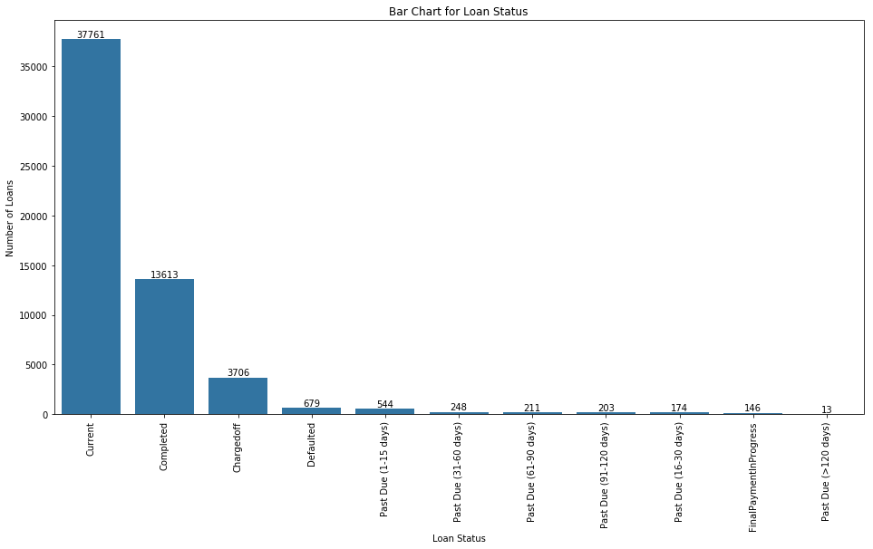

```python
# Set figure size and colour
fig, ax = plt.subplots(figsize = (16, 8))
base_color = sb.color_palette()[0]

# Arrange in descending order
order_sort = loan_df['LoanStatus'].value_counts().index

# Bar chart for LoanStatus
sb.countplot(data=loan_df, x='LoanStatus' , ax=ax, color=base_color, order=order_sort)
plt.title('Bar Chart for Loan Status')
plt.xlabel('Loan Status')
plt.ylabel('Number of Loans')
plt.xticks(rotation = 90)

# Prin values on bars
freq = loan_df.LoanStatus.value_counts()
for i in range(len(freq)):
    count = freq[i]
    plt.text(i,count,count, ha='center', va='bottom');

plt.show;
```

#### Observation(s)

- Most of the loans in the dataset are **current** which is 37761 as shown on plot above.
- Significant number of loans are either completed or chargedoff.
- A number of loans have been defaulted and past due dates, which is a bad trend to the organization.

### What are the reasons for taking loan?

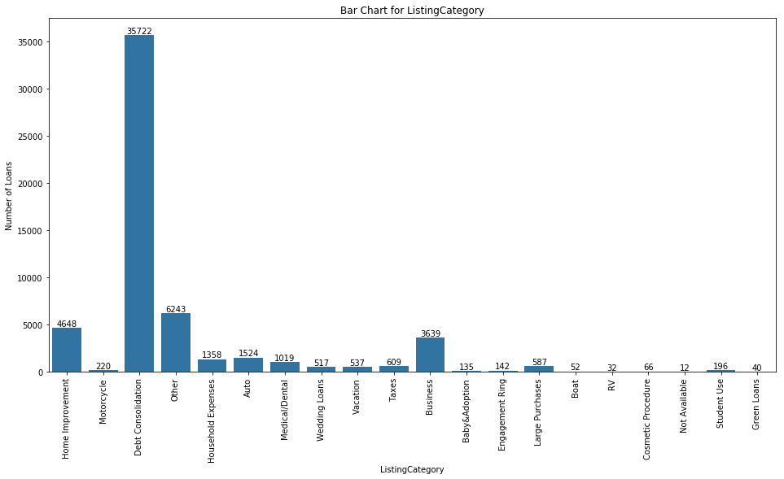

```python
# Set figure size and colour
fig, ax = plt.subplots(figsize = (16, 8))
base_color = sb.color_palette()[0]

# # Arrange in descending order
# order_sort = loan_df['ListingCategory'].value_counts().index

# Bar chart for ListingCategory
sb.countplot(data=loan_df, x='ListingCategory' , ax=ax, color=base_color)
plt.title('Bar Chart for ListingCategory')
plt.xlabel('ListingCategory')
plt.ylabel('Number of Loans')
plt.xticks(rotation=90)

# Prin values on bars
freq = loan_df.ListingCategory.value_counts()
for i in range(len(freq)):
    count = freq[i]
    plt.text(i,count,count, ha='center', va='bottom');

plt.show;
```

#### Observation(s)

- Most loans taken are listed as **Debt Consolidation** with count of 35722, meaning that people were taking loan to pay off other debts they have elsewhere.

### What is the distribution of ProsperScore?

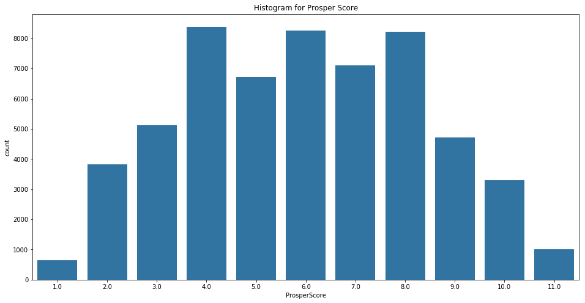

```python
# Set figure size and colour
fig, ax = plt.subplots(figsize = (16, 8))
base_color = sb.color_palette()[0]

# # Arrange in descending order
# order_sort = loan_df['ListingCategory'].value_counts().index

sb.countplot(data=loan_df, x='ProsperScore', ax=ax, color=base_color);
plt.title('Histogram for Prosper Score')
plt.show;
```

#### Observation(s)

- The ProsperScore (as seen in the plot above) shows the most count at 4.0, 6.0 and 8.0 meaning that loans were taken by people with medium-risk score.

### How was loan taken as per state?

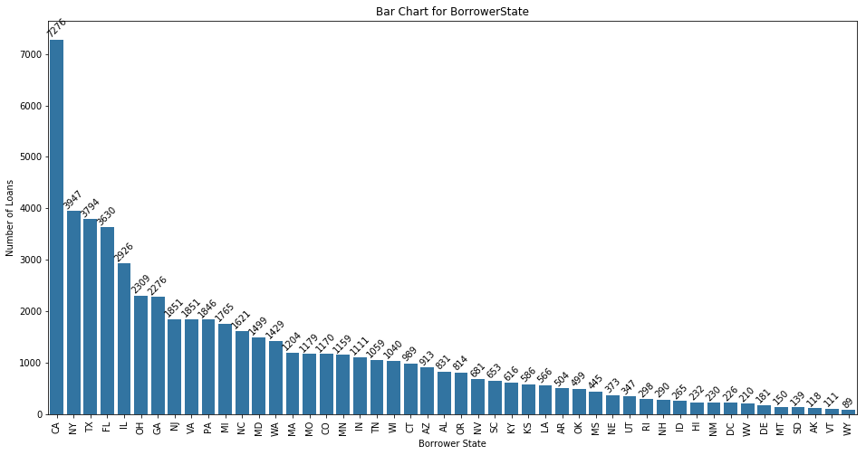

```python
# Set figure size and colour
fig, ax = plt.subplots(figsize = (16, 8))
base_color = sb.color_palette()[0]

# Arrange in descending order
order_sort = loan_df['BorrowerState'].value_counts().index

# Bar chart for BorrowerState
sb.countplot(data=loan_df, x='BorrowerState', ax=ax, color= base_color, order=order_sort)
plt.title('Bar Chart for BorrowerState')
plt.xlabel('Borrower State')
plt.ylabel('Number of Loans')
plt.xticks(rotation=90)

# Print values on bars
freq = loan_df.BorrowerState.value_counts()
for i in range(len(freq)):
    count = freq[i]
    plt.text(i,count,count, ha='center', va='bottom', rotation=45);

plt.show;
```

#### Observation(s)

- From the graph above, California (CA) - 7276, New York (NY) - 3947 and Texas (TX) - 3794 have the highest number of borrowers respectively.
- Wyoming (WY) has the lowest number of borrowers with 89.

### What is the income range of borrowers?

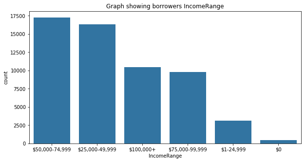

```python
# Set figure size and colour
fig, ax = plt.subplots(figsize = (10, 5))
base_color = sb.color_palette()[0]

sb.countplot(data=loan_df, x='IncomeRange', ax=ax, color=base_color)
plt.title('Graph showing borrowers IncomeRange');
```

#### Observation(s)

- The chart above shows that most of the borrowers earn between **USD 50,000 to USD 74,999**.

### What is the distribution of BorrowerRate?

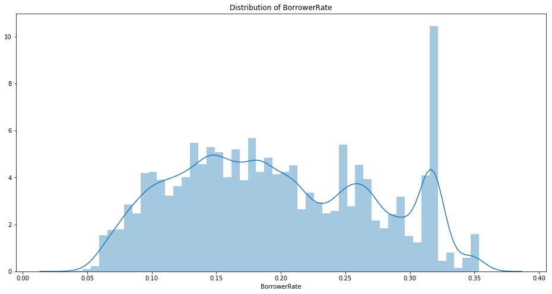

```python
# Set figure size and colour
fig, ax = plt.subplots(figsize = (16, 8))
base_color = sb.color_palette()[0]

# Graph of distribution of BorrowerRate
sb.distplot(loan_df['BorrowerRate'], ax=ax, color=base_color)
plt.title('Distribution of BorrowerRate')
plt.show();
```

#### Observation(s)

- Most loans earn interest rate between 10% to 23%
- The highest Borrower's interest rate is at around 32%.

### How does EmploymentStatus affect loaning?

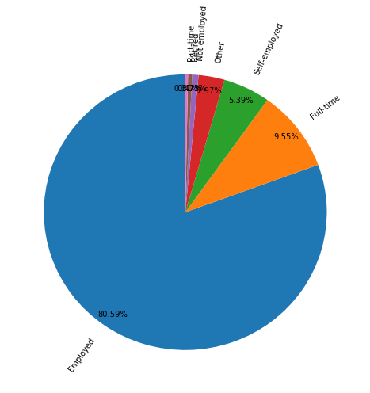

```python
# Set the figure size
plt.figure(figsize=(8,8))

# Pie chart showing EmploymentStatus as percentage
emp_status = loan_df["EmploymentStatus"].value_counts()
lbl = emp_status.index

plt.pie(emp_status, labels=lbl,rotatelabels=True, pctdistance=0.9 , autopct="%.2f%%", startangle=90)
plt.show();
```

#### Observation(s)

- Most loans are given to people who are **Employed**.

### Discuss the distribution(s) of your variable(s) of interest. Were there any unusual points? Did you need to perform any transformations?

> Many borrowers have current loans.

> Most people take loans to pay off other debts they have elsewhere.

> Most borrowers come from California (CA), New York (NY) and Texas (TX) respectively while Wyoming have lowest number of borrowers.

> People with higher income are likely to be given higher amount of loans.

> Most loans are given to people who are Employed.

### Of the features you investigated, were there any unusual distributions? Did you perform any operations on the data to tidy, adjust, or change the form of the data? If so, why did you do this?

> The datatype of the ListingCategory was changed from integer to ordered category as they were categorical data.

## Bivariate Exploration

> Investigating relationships between pairs of variables in data.

### How does EmploymentStatus affect LoanOriginalAmount?

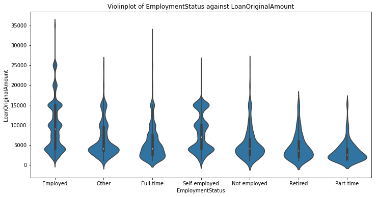

```python
# Set figure size and colour
base_color = sb.color_palette()[0]
plt.figure(figsize=(12,6))

# Violinplot of EmploymentStatus against LoanOriginalAmount
plt.title("Violinplot of EmploymentStatus against LoanOriginalAmount")
sb.violinplot(data=loan_df, x='EmploymentStatus', y='LoanOriginalAmount', color=base_color);
```

#### Observation(s)

- There are more distribution across different loan amounts for the **Employed** meaning that people who are employed are most likely to get loans of higher amounts.
- It can be noticed that people who are **Not employed** or **Retired** or **Part-time** have more distribution around USD 5000 LoanOriginalAmount. This means they are likely to be given lower amount of loan.

### How does Homeownership affect LoanStatus?

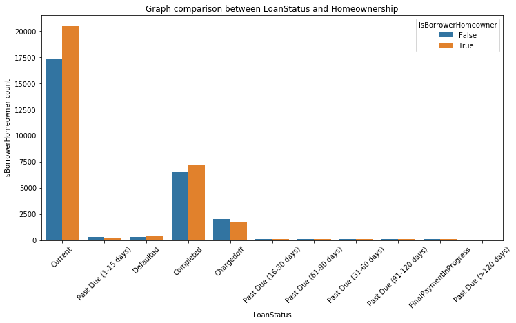

```python
# Set figure size and colour
base_color = sb.color_palette()[0]
plt.figure(figsize=(12,6))

# Graph of LoanStatus and Homeownership
sb.countplot(data=loan_df, x='LoanStatus', hue='IsBorrowerHomeowner')
plt.title('Graph comparison between LoanStatus and Homeownership')
plt.ylabel('IsBorrowerHomeowner count')
plt.xticks(rotation=45);
```

#### Observation(s)

- People who are Homeowners have more **Current** loans compared to those who are not Homeowners.
- Most of people who are Homeowners have **Completed** their loans compared to those who are not Homeowners.

### What is the comparison between IncomeRange and LoanOriginalAmount?

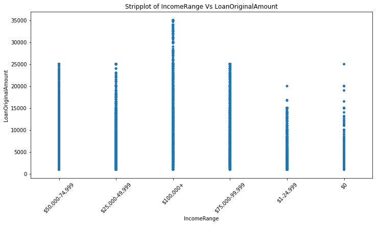

```python
# Set figure size and colour
base_color = sb.color_palette()[0]
plt.figure(figsize=(12,6))

sb.stripplot(data=loan_df, x='IncomeRange', y='LoanOriginalAmount', color=base_color)
plt.title('Stripplot of IncomeRange Vs LoanOriginalAmount')
plt.xticks(rotation=45);
```

### What is the distribution of BorrowerAPR on IncomeRange?

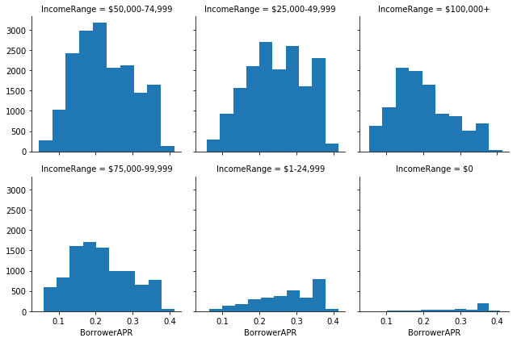

```python
# FacetGrid of BorrowerAPR across IncomeRange
fg = sb.FacetGrid(data=loan_df, col='IncomeRange', col_wrap=3)
fg.map(plt.hist, 'BorrowerAPR');
```

### What is the relationship between LoanStatus and ProsperScore?

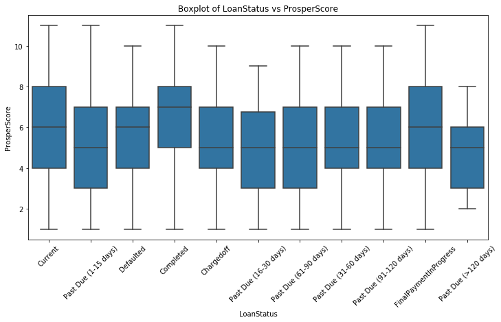

```python
# Set figure size and colour
base_color = sb.color_palette()[0]
plt.figure(figsize=(12,6))

# Boxplot of LoanStatus vs ProsperScore
sb.boxplot(data=loan_df, x='LoanStatus', y='ProsperScore',color=base_color)
plt.title('Boxplot of LoanStatus vs ProsperScore')
plt.xticks(rotation=45);
```

#### Observation(s)

- All loans that are past due dates have higher risk score, meaning that such loans are not likely to be paid easily.

### How often was loan given to high risk borrowers?

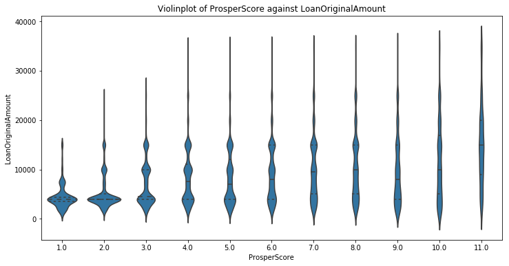

```python
# Set figure size and colour
base_color = sb.color_palette()[0]
plt.figure(figsize=(12,6))

# Violinplot of ProsperScore against LoanOriginalAmount
sb.violinplot(data=loan_df, x='ProsperScore', y='LoanOriginalAmount', color=base_color, inner= 'quartile')
plt.title('Violinplot of ProsperScore against LoanOriginalAmount');
```

#### Observation(s)

- Violin plot above show that people with higher risk score get lower amount of loans as shown by the wide curves while people with lower risk score get higher amount of loans.

### Talk about some of the relationships you observed in this part of the investigation. How did the feature(s) of interest vary with other features in the dataset?

> People who are Employed get higher loan amounts while people who are Not employed or Retired or Part-time get lower loan amounts

> Loans that are past due dates have higher risk score, meaning that such loans are not likely to be paid easily.

> Pople with lower risk score get higher amount of loans while people with higher risk score get lower amount of loans.

## Multivariate Exploration

> Plots of three or more variables to investigate data further.

### How does BorrowerAPR affect LoanStatus with respect to IsBorrowerHomeowner?

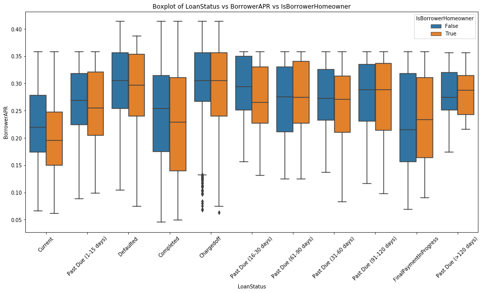

```python
# Set figure size
plt.figure(figsize=(16,8))

# Boxplot of LoanStatus vs BorrowerAPR vs IsBorrowerHomeowner
sb.boxplot(data=loan_df, x="LoanStatus", y="BorrowerAPR", hue='IsBorrowerHomeowner')
plt.xticks(rotation=45)
plt.xlabel('LoanStatus')
plt.ylabel('BorrowerAPR')
plt.title('Boxplot of LoanStatus vs BorrowerAPR vs IsBorrowerHomeowner');
```

#### Observation(s)

- Boxplot above shows that in most categories of LoanStatus, borrowers who are Homeowners have lower BorrowerAPR compared to those who are not Homeowners.

### What is the comparison between LenderYield, BorrowerRate and ProsperScore?

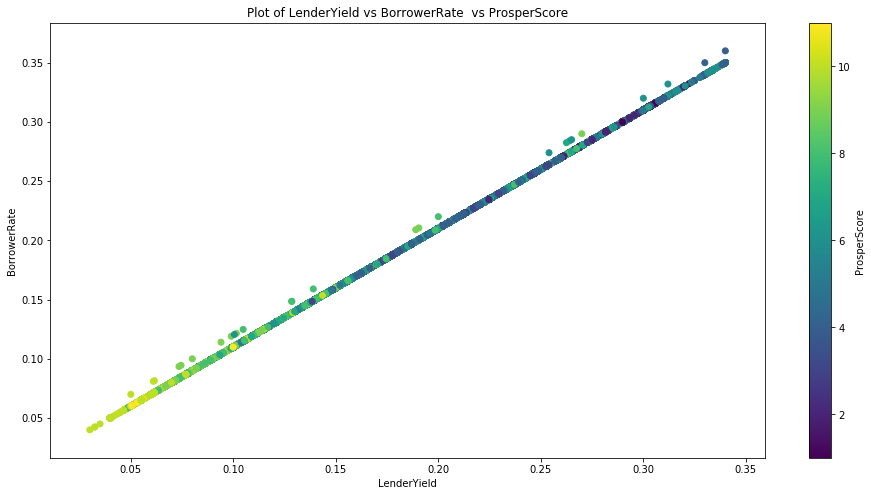

```python
# Set figure size
plt.figure(figsize = [16, 8])

# LenderYield, BorrowerRate and ProsperRating
plt.scatter(data=loan_df, x='LenderYield', y='BorrowerRate', c='ProsperScore')
plt.colorbar(label = 'ProsperScore')
plt.title('Plot of LenderYield vs BorrowerRate  vs ProsperScore')
plt.xlabel('LenderYield')
plt.ylabel('BorrowerRate');
```

#### Observation(s)

- There is a positive relationship between BorrowerRate and LenderYield. This correlation shows that when loans of higher BorrowerRate are paid, the LenderYield increases.
- The higher the ProsperScore the lower the BorrowerRate and LenderYield.

### What is the correlation between numeric variables?

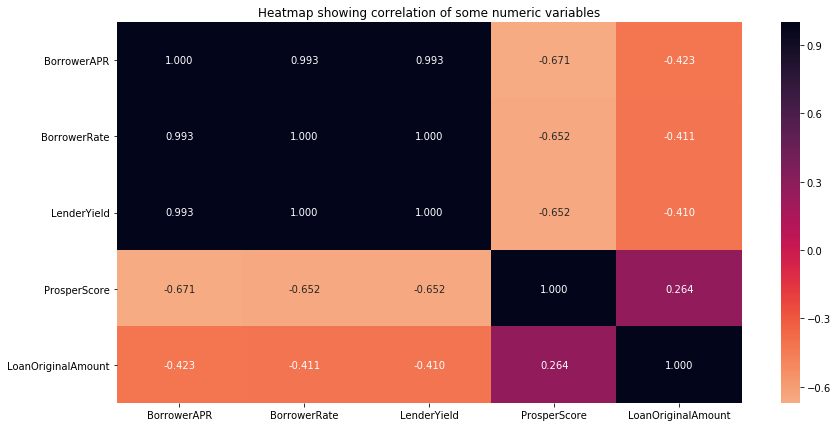

```python
# Set figure size
plt.figure(figsize = [14, 7])

# Some numeric variables
numeric_vars = ['BorrowerAPR','BorrowerRate','LenderYield','ProsperScore','LoanOriginalAmount']

# Correlation plot using Heatmap
sb.heatmap(loan_df[numeric_vars].corr(), annot = True, fmt = '.3f', cmap = 'rocket_r', center = 0)
plt.title('Heatmap showing correlation of some numeric variables')
plt.show();
```

#### Observation(s)

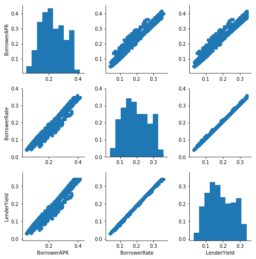

```python
# PairGrid plot of 3 variables
fg = sb.PairGrid(data = loan_df, vars = ['BorrowerAPR', 'BorrowerRate', 'LenderYield'])
fg.map_diag(plt.hist)
fg.map_offdiag(plt.scatter);
```

#### Observation(s)

- The pairgrid above shows a positive correlation between BorrowerAPR, BorrowerRate and LenderYield.

### What is variation between BorrowerRate and Term on ProsperScore?

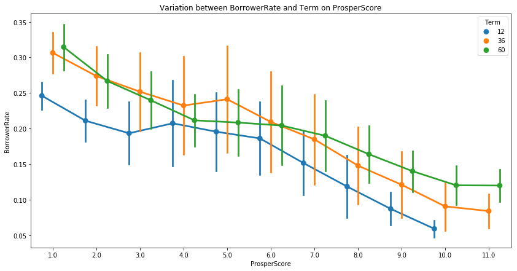

```python
# Set figure size
plt.figure(figsize=(14,7))

# Pointplot
sb.pointplot(data=loan_df, x='ProsperScore', y='BorrowerRate', hue='Term', palette='tab10',
             linestyle='', dodge=0.5, ci='sd')
plt.title('Variation between BorrowerRate and Term on ProsperScore')
plt.ylabel('BorrowerRate');
```

#### Observation(s)

- There is decrease of BorrowerRate with increase in ProsperScore with loans of 12 months Term being the lowest in the graph.

### Talk about some of the relationships you observed in this part of the investigation. Were there features that strengthened each other in terms of looking at your feature(s) of interest?

> Observing different categories of LoanStatus, borrowers who are Homeowners have lower BorrowerAPR compared to those who are not Homeowners.

> There is a positive correlation between BorrowerAPR, BorrowerRate and LenderYield.

### Were there any interesting or surprising interactions between features?

> Homeowners have lower BorrowerAPR compared to those who are not homeowners.This surprising.

## Conclusions

- Most loans were taken for debt consolidation.
- Loans with high lender yield have high risk.
- People with high income range or employed get more loans.
- Loans that have gone past due dates (>120 days) risk not getting paid.
- Most borrowers come from California (CA), New York (NY) and Texas (TX) respectively.